# データ解析論II第12講

## 前回の復習

## ランダム比較化実験とは

## 因果推論とは：

- 因果推論：原因と結果の関係，因果関係を明らかにするための手法
- いわゆる回帰分析やロジスティック回帰分析でやってきたことは「相関関係」を明らかにするのであって，因果関係はわからない．
  - でも，ホントは因果関係を知りたいことが多い．
- 因果関係を明らかにするには「実験」が採用の手段
  - 世の中実験ができれば最高！
  - しかし，必ずしも実験ができないこともたくさんある．．．

## 相関関係と因果関係における「同時性」

- 同時性：2つの事柄について，互いが互いの原因であり，同時に結果であること．
  - ex. 地域における警察官数と刑法犯認知件数は正の相関がある．犯罪が多い地域には警察官がたくさん必要だが，警察官がいる地域では刑法犯認知件数が増える

## RCT：

- ランダム化比較実験：「介入」の効果を適切に分析する手法であり，実験群と統制群に分けて影響を検討する方法
- - [参考](https://www.rieti.go.jp/jp/columns/s18_0009.html)
  - 実験的な介入ができれば良いけど，できないことも多い．

## ルービンの因果モデル

- 反実仮想の状態はわからない．
  - ex.今日のお昼にオムライスを食べたゴトウの体重（介入群）と，今日のお昼にオムライスを食べなかったゴトウの体重（非介入群）を比べたいけど，食べたゴトウと食べていないゴトウは同時に存在し得ない．

\[ Y_i= \begin{cases} Y_{1i} & ( if\ T_i=1 ) \\ Y_{0i} & ( if\ T_i=0 ) \end{cases} \]

- 一番知りたいのは\(Y_{1i}-Y_{0i}\)
  - この差分が介入の効果となる．
- 反実仮想を想定しながら考えていくのがルービンの因果モデル

## 平均介入効果（Average Treatment Effect）

- 平均介入効果：複数人の介入効果を平均したもの
  - これを評価すれば，介入効果の大きさを推定できる！
  - \(E[Y_{1i}-Y_{0i}]\)

## 平均介入効果のシミュレーション例

```r
n <- 400
T <- rbinom(n, 1, 0.6)# 確率0.6で1（介入群）をとり，確率0.4で0（統制群）をとる変数
TE <- 2 # トリートメント効果，個人差はない
Y <- TE*T + rnorm(n)
```

## 平均値の算出

```r
EY1 <- sum(T*Y)/sum(T)
EY0 <- sum((1-T)*Y)/sum(1-T)
EY1-EY0
```

```
## [1] 1.875349
```

- おおよそ2に近い値であり，推定値としてかなり妥当性がある．

## 他の変数の影響

```r
Z <- runif(n) # TとYに共通して影響を与える変数
T <- rbinom(n, 1, Z) # Zが大きいほど1をとりやすいトリートメント変数
Y <- TE*T + (2*Z -1) + rnorm(n)
```

\(Y = treatment_effect * T + (2Z -1) + \epsilon\)

## 平均値の算出

```r
EY1 <- sum(T*Y)/sum(T)
EY0 <- sum((1-T)*Y)/sum(1-T)
EY1-EY0
```

```
## [1] 2.667845
```

- 変数同士の相関がある＝群分けがうまく行かず，ランダム化がきれいに出来ていないと，推定値が大きくずれてしまう．

## 群わけの注意

- 良くないグループ分けの例
  - 自己選抜：個人が自らの意志で介入を受けるか受けないかを決めること
  - 自己選抜によって形成された介入群と統制群は違った特性を持つ可能性が高まってしまう
- 良いグループ分け
  - グループ分けをランダム（＝無造作，適当）に分けよう．
  - ex. くじ引きなど

## ランダム化の方法

- 単純ランダム化
  - 実験参加者のリストをランダムに並べ変えて上から順に介入群，比較群に分ける。
- 層化ランダム化
  - 同じ特性を持つ参加ブロックに分けブロック内で乱数を用いたランダム化を行う
- RCTを実施すると非常に結果もわかりやすいが，色々準備も必要
  - 特にランダム化比較実験の「倫理」は個人的には重要だと思っている．

## マッチング法

## マッチング法

[今日のテキスト](https://elib.maruzen.co.jp/elib/html/Viewer/Id/3000040168?8#)

- マッチング法：介入群によく似たサンプルを統制群の中から選び出すことで，2つのグループを比較可能とする方法
  - ex.今日のお昼にオムライスを食べたゴトウの体重と今日のお昼にオムライスを食べなかったゴトウ**のそっくりさん**の体重を比べれば，オムライスを食べたこと（＝介入）の効果を明らかにできる．
- あわせて，共変量もコントロールすることがある．
  - 共変量：年齢など，結果に影響を与えるような数値のこと
  - 複数の共変量が存在する場合には「プロペンシティスコアマッチング（傾向スコアマッチング）」という．

## データの読み込み

**[データ](https://www.dropbox.com/sh/3qq2wnxw4s464mp/AAD3TJkpstHT0Bug8sTeldZ-a?dl=0)**

```r
wt <- read_csv("../data/wt.csv")
```

## データの確認

|  | wagea | T | years | wageb |
| --- | --- | --- | --- | --- |
| 1 | 19 | 1 | 4 | 18 |
| 2 | 27 | 0 | 22 | 27 |
| 3 | 20 | 1 | 2 | 18 |
| 4 | 36 | 1 | 14 | 34 |
| 5 | 28 | 0 | 6 | 28 |
| 6 | 18 | 0 | 4 | 18 |
| 7 | 31 | 0 | 19 | 31 |
| 8 | 29 | 0 | 19 | 29 |
| 9 | 30 | 0 | 21 | 30 |
| 10 | 24 | 0 | 12 | 23 |

[output cut: 790 more lines]

## データの確認

- wagea：研修後の平均年収
- T：研修の参加有無(0：なし（非介入群），1：あり（介入群）)
- years：経験年数
- wageb：研修以前の平均年収

## 介入群と非介入群の比較

- 介入以降の賃金差を比較
  - 介入群の方が小さい

```r
cor(wt$T,wt$wagea)
```

```
## [1] -0.09667485
```

## 介入群と非介入群の比較

```r
t.test(wagea ~ T, wt)
```

```
##
##  Welch Two Sample t-test
##
## data:  wagea by T
## t = 2.9866, df = 546.19, p-value = 0.002947
## alternative hypothesis: true difference in means is not equal to 0
## 95 percent confidence interval:
##  0.3862762 1.8706992
## sample estimates:
## mean in group 0 mean in group 1
##        26.84698        25.71849
```

## 介入群と非介入群の比較

- 介入群（研修参加群）- 非介入群（研修非参加群）

```r
sum(wt$T*wt$wagea)/sum(wt$T)-
  sum((1-wt$T)*wt$wagea)/sum(1-wt$T)
```

```
## [1] -1.128488
```

## 介入群と非介入群の比較

- 念のためにt検定も実施
  - 参加した人の方が賃金が低い．

```r
t.test(wagea ~ T, wt)
```

```
##
##  Welch Two Sample t-test
##
## data:  wagea by T
## t = 2.9866, df = 546.19, p-value = 0.002947
## alternative hypothesis: true difference in means is not equal to 0
## 95 percent confidence interval:
##  0.3862762 1.8706992
## sample estimates:
## mean in group 0 mean in group 1
##        26.84698        25.71849
```

## 介入群と非介入群の比較

- 介入の有無と経験年数の相関．
  - 介入群の方が低い．

```r
cor(wt$T,wt$years)
```

```
## [1] -0.1908208
```

## 介入群と非介入群の比較

- 2群のt検定を実施
  - 介入群の方が低い．

```r
t.test(years ~ T, wt)
```

```
##
##  Welch Two Sample t-test
##
## data:  years by T
## t = 5.9758, df = 545.85, p-value = 4.134e-09
## alternative hypothesis: true difference in means is not equal to 0
## 95 percent confidence interval:
##  1.816931 3.596329
## sample estimates:
## mean in group 0 mean in group 1
##       10.937722        8.231092
```

## 介入群と非介入群の比較

- 介入以前の賃金差を比較

```r
cor(wt$T,wt$wageb)
```

```
## [1] -0.1839177
```

## 介入群と非介入群の比較

- 介入以前の賃金差を比較

```r
t.test(wageb ~ T, wt)
```

```
##
##  Welch Two Sample t-test
##
## data:  wageb by T
## t = 5.7219, df = 538.81, p-value = 1.749e-08
## alternative hypothesis: true difference in means is not equal to 0
## 95 percent confidence interval:
##  1.429162 2.923451
## sample estimates:
## mean in group 0 mean in group 1
##        26.66370        24.48739
```

## 介入群と非介入群の比較

- 非介入群に比べて，介入群の研修以降の給与が低い
  - 研修の効果はない？？
- 非介入群に比べて，介入群の勤続年数が短い
- 非介入群に比べて，介入群の研修以前の給与が低い

## パッケージのインストール＆読み込み

```r
# install.packages("Matching", dependencies = T)
library(Matching)
```

## 使う関数について

- 関数Match()では以下のような記法を行う

```
Match(成果変数，介入変数，共変量，距離尺度の選択)
```

- 共変量が複数ある場合は「行列形式」or「cbind()」で複数変数をまとめる．
- 距離変数は標準化ユークリッド距離を用いる場合には「Weight=1」，マハラノビス距離を用いる場合は「Weight=2」を用いる．

## 計算の実行（ユークリッド距離）

```r
NN.Euclid <-  Match(wt$wagea, wt$T,
                    cbind(wt$years, wt$wageb),
                    Weight=1)
summary(NN.Euclid)
```

```
##
## Estimate...  1.0474
## AI SE......  0.042
## T-stat.....  24.938
## p.val......  < 2.22e-16
##
## Original number of observations..............  800
## Original number of treated obs...............  238
## Matched number of observations...............  238
## Matched number of observations  (unweighted).  838
```

## 計算の実行（マハラノビス距離）

```r
NN.Mahalanobis <-  Match(wt$wagea, wt$T,
                         cbind(wt$years, wt$wageb),
                         Weight=2)
summary(NN.Mahalanobis)
```

```
##
## Estimate...  1.0429
## AI SE......  0.047072
## T-stat.....  22.155
## p.val......  < 2.22e-16
##
## Original number of observations..............  800
## Original number of treated obs...............  238
## Matched number of observations...............  238
## Matched number of observations  (unweighted).  883
```

## 計算の実行（厳密なマッチング）

```r
exact_matching <-  Match(wt$wagea, wt$T,
                         cbind(wt$years, wt$wageb),
                         exact = TRUE)
summary(exact_matching)
```

```
##
## Estimate...  1.0439
## AI SE......  0.045154
## T-stat.....  23.12
## p.val......  < 2.22e-16
##
## Original number of observations..............  800
## Original number of treated obs...............  238
## Matched number of observations...............  204
## Matched number of observations  (unweighted).  738
##
## Number of obs dropped by 'exact' or 'caliper'  34
```

## 本当は…

- 今回のデータはある程度これでも行ける
  - ただ，今回の場合は使える変数が少ないから．
  - もう少し変数が多い場合は適していない．

```r
model <-lm(wagea ~ wageb + T + years, wt)
summary(model)
```

```
##
## Call:
## lm(formula = wagea ~ wageb + T + years, data = wt)
##
## Residuals:
##     Min      1Q  Median      3Q     Max
## -1.2362 -0.2153 -0.1866 -0.1330  1.7407
##
## Coefficients:
##              Estimate Std. Error t value Pr(>|t|)
## (Intercept)  0.230963   0.090374   2.556   0.0108 *
## wageb        1.000120   0.004327 231.111   <2e-16 ***
## T            1.035488   0.032827  31.544   <2e-16 ***
## years       -0.004652   0.003615  -1.287   0.1985
## ---
## Signif. codes:  0 '***' 0.001 '**' 0.01 '*' 0.05 '.' 0.1 ' ' 1
##
## Residual standard error: 0.416 on 796 degrees of freedom
## Multiple R-squared:  0.994,  Adjusted R-squared:  0.9939
## F-statistic: 4.362e+04 on 3 and 796 DF,  p-value: < 2.2e-16
```

## 傾向スコアマッチング

## 傾向スコアマッチングとは？

- 傾向スコア：複数の共変量をまとめて一つの得点にしたもの
  - 傾向スコアを用いたマッチング法を傾向スコアマッチングという

## パッケージの読み込み＆データの確認

- Matchingパッケージの中のlalondeデータセットを使います．

```r
library(Matching)
```

- age：年齢
- educ：教育年数
- race：人種
  - black：黒人かどうか
  - hisp：ヒスパニックかどうか

## NSW職業データ

- married：結婚しているかどうか
- nodegree：高校卒業有無
- re74：74年実質賃金
- re75：75年実質賃金
- re78：78年実質賃金
- u74：74年の賃金が0かどうか
- u78：78年の賃金が0かどうか
- treat：NSW対象者有無

## パッケージの読み込み＆データの確認

```r
library(readr)
lalonde <- read_csv("../data/lalonde.csv")
head(lalonde)
```

```
## # A tibble: 6 x 10
##   X1    treat   age  educ race   married nodegree  re74  re75   re78
##   <chr> <dbl> <dbl> <dbl> <chr>    <dbl>    <dbl> <dbl> <dbl>  <dbl>
## 1 NSW1      1    37    11 black        1        1     0     0  9930.
## 2 NSW2      1    22     9 hispan       0        1     0     0  3596.
## 3 NSW3      1    30    12 black        0        0     0     0 24909.
## 4 NSW4      1    27    11 black        0        1     0     0  7506.
## 5 NSW5      1    33     8 black        0        1     0     0   290.
## 6 NSW6      1    22     9 black        0        1     0     0  4056.
```

## 傾向スコアの算出：

- ロジスティック回帰分析を用いて，傾向スコアを算出する．
  - 授業の中で紹介しますが，変わった書き方をしています．

```r
model <- glm(treat ~ age+ educ+ race+
               married+ nodegree + re74 + re75,
             lalonde, family ="binomial")
```

## 傾向スコアの算出：

- ロジスティック回帰分析を用いて，傾向スコアを算出する．

```r
summary(model)
```

```
##
## Call:
## glm(formula = treat ~ age + educ + race + married + nodegree +
##     re74 + re75, family = "binomial", data = lalonde)
##
## Deviance Residuals:
##     Min       1Q   Median       3Q      Max
## -1.7645  -0.4736  -0.2862   0.7508   2.7169
##
## Coefficients:
##               Estimate Std. Error z value Pr(>|z|)
## (Intercept) -1.663e+00  9.709e-01  -1.713  0.08668 .
## age          1.578e-02  1.358e-02   1.162  0.24521
## educ         1.613e-01  6.513e-02   2.477  0.01325 *
## racehispan  -2.082e+00  3.672e-01  -5.669 1.44e-08 ***
## racewhite   -3.065e+00  2.865e-01 -10.699  < 2e-16 ***
## married     -8.321e-01  2.903e-01  -2.866  0.00415 **
## nodegree     7.073e-01  3.377e-01   2.095  0.03620 *
## re74        -7.178e-05  2.875e-05  -2.497  0.01253 *
## re75         5.345e-05  4.635e-05   1.153  0.24884
## ---
## Signif. codes:  0 '***' 0.001 '**' 0.01 '*' 0.05 '.' 0.1 ' ' 1
##
## (Dispersion parameter for binomial family taken to be 1)
##
##     Null deviance: 751.49  on 613  degrees of freedom
## Residual deviance: 487.84  on 605  degrees of freedom
## AIC: 505.84
##
## Number of Fisher Scoring iterations: 5
```

## MatchingパッケージのMatch()

- Match(Y, Tr, X, caliper=F)
  - Y：結果ベクトル（応答変数）
  - Tr：割り当てベクトル（ロジスティック回帰の応答変数）
  - X：共変量または傾向スコア

## マッチングによる因果効果の推定

```r
nsw1 <- Match(Y = lalonde$re78, Tr =lalonde$treat,
              X= model$fitted.values)
```

```r
ps.reg <- lm(lalonde$re78~lalonde$treat+model$fitted.values)
summary(ps.reg)
```

```
##
## Call:
## lm(formula = lalonde$re78 ~ lalonde$treat + model$fitted.values)
##
## Residuals:
##    Min     1Q Median     3Q    Max
##  -8925  -5632  -2148   3993  54953
##
## Coefficients:
##                     Estimate Std. Error t value Pr(>|t|)
## (Intercept)           7833.8      430.7  18.188  < 2e-16 ***
## lalonde$treat         1207.6      834.1   1.448 0.148200
## model$fitted.values  -4662.4     1319.4  -3.534 0.000441 ***
## ---
## Signif. codes:  0 '***' 0.001 '**' 0.01 '*' 0.05 '.' 0.1 ' ' 1
##
## Residual standard error: 7402 on 611 degrees of freedom
## Multiple R-squared:  0.02152,    Adjusted R-squared:  0.01832
## F-statistic:  6.72 on 2 and 611 DF,  p-value: 0.001298
```

## マッチングによる因果効果の推定

```r
summary(nsw1)
```

```
##
## Estimate...  1933.4
## AI SE......  1090.6
## T-stat.....  1.7728
## p.val......  0.076267
##
## Original number of observations..............  614
## Original number of treated obs...............  185
## Matched number of observations...............  185
## Matched number of observations  (unweighted).  287
```

## 回帰不連続デザイン

## 回帰不連続デザインとは？

- 介入の割り当てがルールによって行われている場合に利用できる分析手法
  - 介入が何らかの「カットオフ値」（閾値）によって割り当てられている場合に用いられる
  - ex昨年の売上額\(history_i\)がA円以上の場合にメール配信という介入を行う場合における介入の有無\(Z_i\)

\[ Z_i= \begin{cases} 1 & ( if history_i \geqq A_i ) \\ 0 & ( if history_i \leq 1 ) \end{cases} \]

## 今回のデータの概要

- ある大学における講義は前期後期制であり，100点満点のテストを実施している．
- 前期試験でc点以下だった場合には夏休みに補習に参加しなければならない．
  - c点よりも得点が高い場合は補習には参加しない．
  - cは既知の値とする

\[ Z_i= \begin{cases} 1 & ( if Z_i< c ) \\ 0 & ( if Z_i \leqq c ) \end{cases} \]

- \(Z_i\)：強制変数
  - トリートメントの状態を決定する変数
  - 今回の例で言えば前期試験のスコア
- Z：前期試験の点数
- Y：後期試験の点数

## データの読み込み

**[データ](https://www.dropbox.com/sh/8s7c4yerrjdniwb/AADcd5EXriPcOLDgV4dgJ4OMa?dl=0)**

```r
test<- read_csv("../data/test.csv")
head(test)
```

```
## # A tibble: 6 x 2
##       Y     Z
##   <dbl> <dbl>
## 1  72.7  57.0
## 2  76.9  75.3
## 3  51.0  64.3
## 4  77.2  73.3
## 5  72.5  45.0
## 6  53.0  71.8
```

## 散布図の作成

```r
library(ggplot2)
graph <- ggplot(test, aes(x = Z, y = Y)) +
  geom_point() +
  theme_bw() + geom_vline(xintercept=60)
```

## 散布図の作成

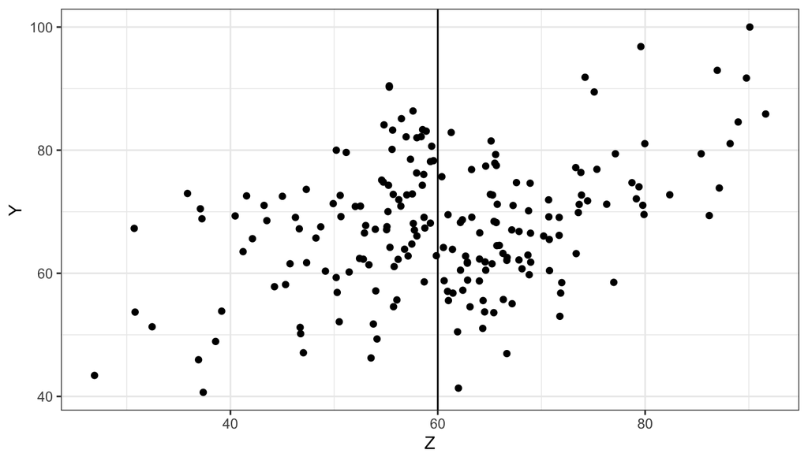

```r
graph
```

## データの確認

- 全体的には春学期のスコアが高いと，秋学期のスコアも高い．
- \(Z=60\)周辺に注目すると，トリートメント群（補講参加群）の方が，コントロール群（補講不参加群）に加えてスコアが高い．
- ギリギリ単位を落として補習に参加した人よりも，ギリギリで単位を落として補習に参加しなかった人の方がスコアが低くなる？

## トリートメント群を示すダミー変数を作成する．

```r
Y <- test$Y
Z <- test$Z
Tre <- ifelse(Z < 60, 1, 0)
test$Tre <- as.factor(ifelse(Z < 60, 1, 0))
```

- 今回はデータフレームに入れずに分析をする．
- グラフ作成用にtestデータフレームに入れたものも作る．

## 散布図に回帰直線を足す

```r
# The code below will generate the graph:
graph <- ggplot(test, aes(x = Z, y = Y, colour = Tre)) +
  geom_point()+
  geom_smooth(se = FALSE, method = 'lm') +
  theme_bw()
```

## 散布図の作成

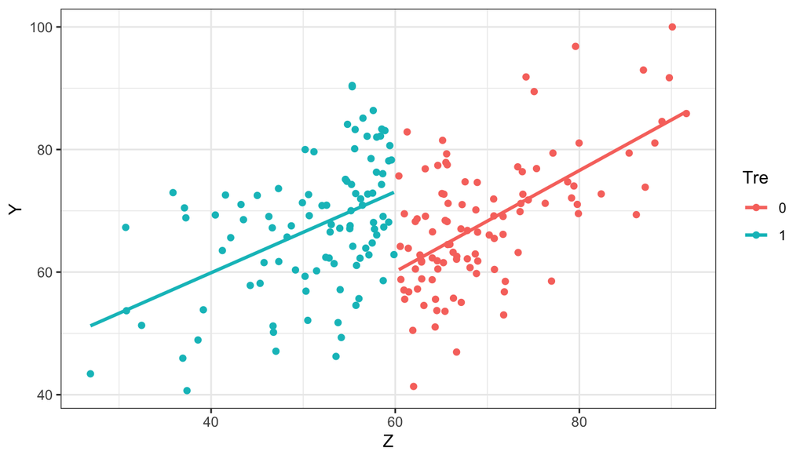

```r
graph
```

## 回帰式の作成

```r
X <- cbind(Tre, Tre*(Z-60), (1-Tre)*(Z-60))
model <-lm(Y~X)
```

- 2本の数式に分けて考えてみるイメージ

## 式の整理

- 60点未満の場合

\(E[Y_{0i}|Z_i]=\alpha_1 + \beta_1(Z_i-c)\)

- 60点以上の場合

\(E[Y_{0i}|Z_i]=\alpha_0 + \beta_0(Z_i-c)\)

- 平均トリートメント効果 \(\tau = E[Y_{1i}|Z_i]-E[Y_{0i}|Z_i]\)

## 式の整理

- 2本合わせる

\(E[Y_{1i}|Z_i, T_i]=T_i(\alpha_1 + \beta_1(Z_i-c))\) \(+ (1-T_i)(\alpha_0 + \beta_0(Z_i-c))\) \(=\alpha_0 + \tau*T_i + \beta_i*T_i(Z_i-c) + \beta_0*(1-T_i)(Z_i-c)\)

- ここから\((\alpha_0, \tau, \beta_1, \beta_0)\)を推定可能
- \(\epsilon =Y_i - E[Y_{1i}|Z_i, T_i]\)とする．

## 分析結果

```r
summary(model)
```

```
##
## Call:
## lm(formula = Y ~ X)
##
## Residuals:
##      Min       1Q   Median       3Q      Max
## -22.6094  -5.7117  -0.6302   5.8505  21.7367
##
## Coefficients:
##             Estimate Std. Error t value Pr(>|t|)
## (Intercept)  60.0665     1.4556  41.266  < 2e-16 ***
## XTre         13.0402     2.0336   6.412 1.05e-09 ***
## X             0.6606     0.1214   5.444 1.55e-07 ***
## X             0.8256     0.1154   7.153 1.65e-11 ***
## ---
## Signif. codes:  0 '***' 0.001 '**' 0.01 '*' 0.05 '.' 0.1 ' ' 1
##
## Residual standard error: 9.131 on 196 degrees of freedom
## Multiple R-squared:  0.2935, Adjusted R-squared:  0.2826
## F-statistic: 27.13 on 3 and 196 DF,  p-value: 1.011e-14
```

## 非線形回帰を実施する場合

- 経済支援型の奨学金の受給が学業成績に与える影響の検証
- ある大学では家計収入が年間400万円以下の学生に対して，一定額の奨学金を付与しているとする．
- GPA：Grade Point Average
- inc：家計収入（単位：万円）

\[ Z_i= \begin{cases} 1 & ( if\ inc \leqq 400 ) \\ 0 & ( if\ inc > 400 ) \end{cases} \]

## データの読み込み

**[データ](https://www.dropbox.com/sh/8s7c4yerrjdniwb/AADcd5EXriPcOLDgV4dgJ4OMa?dl=0)**

```r
scholarship <- read_csv("../data/scholarship.csv")
head(scholarship)
```

```
## # A tibble: 6 x 2
##     GPA   inc
##   <dbl> <dbl>
## 1  1.70   615
## 2  2.28   731
## 3  1.45   510
## 4  3.28   934
## 5  2.20   336
## 6  1.45   269
```

## パッケージのインストール＆読み込み

```r
# install.packages("rdd", dependencies = T)
library(rdd)
```

## 数字の整理

```r
scholarship$inc100 <- -scholarship$inc/100
```

- 奨学金の負債額なので，“-”にしておく

## 散布図の作成

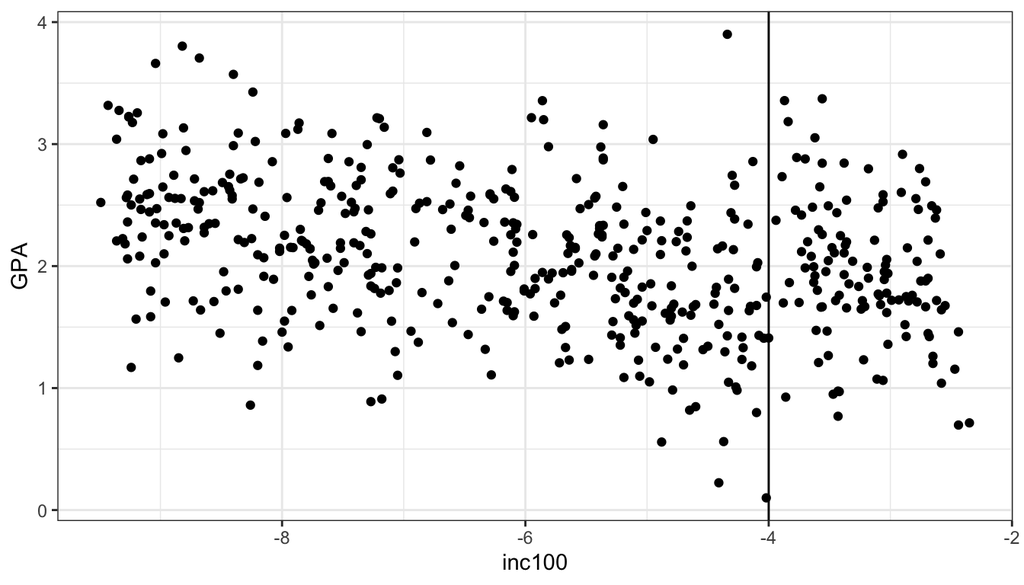

```r
library(ggplot2)
graph <- ggplot(scholarship, aes(x = inc100, y = GPA)) +
  geom_point() +
  theme_bw() + geom_vline(xintercept=-4)
graph
```

## 散布図の作成

- 回帰不連続デザインの最初には必ず散布図を確認する
  - ggplotguiを使って可視化しておこう．
  - ついでに，理解しやすいように閾値で線を引いておいた．

## 強制変数の影響を確認

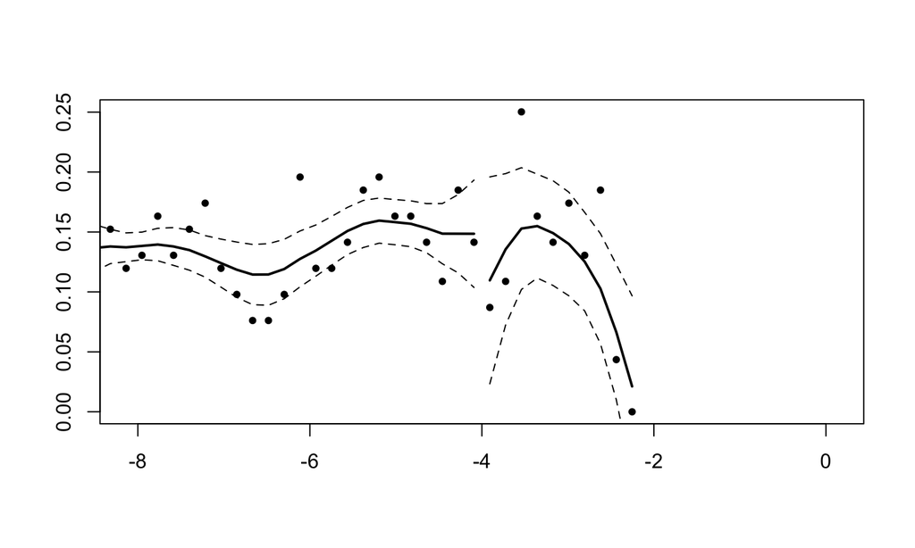

```r
p <-DCdensity(scholarship$inc100, -4, plot=TRUE)
```

```r
p
```

```
## [1] 0.2248964
```

- DCdensity(強制変数, 閾値，plot = TRUE/FALSE)
  - Z>cであればトリートメントグループとなるような閾値cを設定する
  - 強制変数の密度関数の推定値をプロットする場合は`TRUE`，プロットしない場合は`FALSE`とする．
- p値は十分大きいので，強制変数の影響は気にしなくて良い．

## 局所回帰分析

```r
results<-RDestimate(GPA ~ inc100,scholarship, cutpoint = -4,
                    kernel = "rectangular")
```

- RDestimate関数は局所線形回帰を用いて，Z=cにおける条件付き平均トリートメント効果の推定値を計算するコマンド
  - 必ずしも非線形回帰をしている場合に行う分析手法

## 結果の確認

```r
summary(results)
```

```
##
## Call:
## RDestimate(formula = GPA ~ inc100, data = scholarship, cutpoint = -4,
##     kernel = "rectangular")
##
## Type:
## sharp
##
## Estimates:
##            Bandwidth  Observations  Estimate  Std. Error  z value  Pr(>|z|)
## LATE       3.167      333           0.6079    0.1505      4.038    5.391e-05
## Half-BW    1.583      240           0.7207    0.1771      4.068    4.732e-05
## Double-BW  6.333      500           0.5273    0.1377      3.829    1.284e-04
##
## LATE       ***
## Half-BW    ***
## Double-BW  ***
## ---
## Signif. codes:  0 '***' 0.001 '**' 0.01 '*' 0.05 '.' 0.1 ' ' 1
##
## F-statistics:
##            F       Num. DoF  Denom. DoF  p
## LATE       11.808  3         329         4.60e-07
## Half-BW     7.643  3         236         1.35e-04
## Double-BW  32.542  3         496         0.00e+00
```